# Practical II

## The simulation framework

### Install

Borrow from Thompson et al. (2020) and slightly modified.

To install from GitHub

```r
devtools::install_github("mxdub/TMDSpatial")
```

You’ll also need JAGS and R2jags :

JAGS can be download & installed from : https://sourceforge.net/projects/mcmc-jags/files/

R2jags, with the install.package() from R.

```r
library(TMDSpatial)
library(R2jags)
# Some additional packages might be needed:
library(tidyverse)
```

### Use

Function is quickly described on GitHub - see Thompson et al. (2020) for details on implementation. The overall idea :

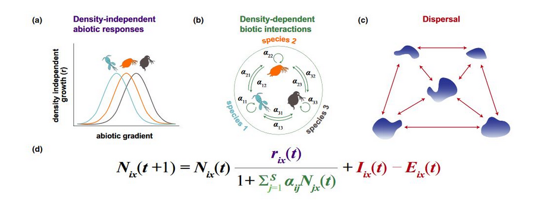

We are going to use only the simulation function : *simulate_MC()*. All parameters can be view in the help (?simulate_MC()). Main parameters are already set for our use here.

For occupancy models, we will use only two species.

The typical use of that function :

```r
n_patch = 200
n_species = 2

# Define environmental optima
envt_opt = c(0.35, 0.65)

sim = simulate_MC(patches = n_patch,     # Number of patch
                  species = n_species,   # Number of species
                  kernel_exp = 0.001,    # Rate of decrease of disp. kernel (e.g. P(disp) = exp(-kernel_exp*dist(i,j)))
                  env1Scale = 100,       # Low spatial autocorrelation for envt (not important)
                  env_optima = envt_opt, # Environmental effects are Gaussian around optimum
                  env_niche_breadth = 0.07, # Niche breadth (~ sd of the Gaussian)
                  int_mat = matrix( c(0.05,0.00,
                                      0.00,0.05) , nrow = 2, ncol = 2), # Interaction matrix
                  local_start = F) # Whether to start with clusered pop. or not
```

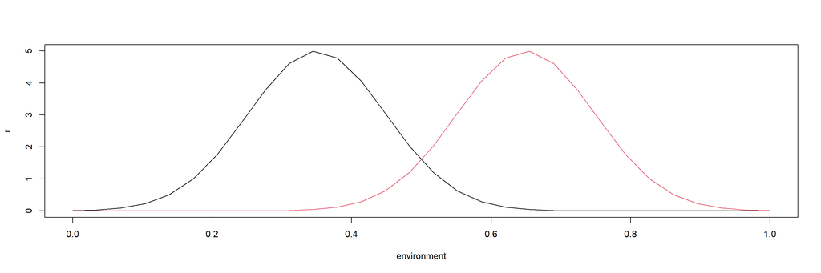

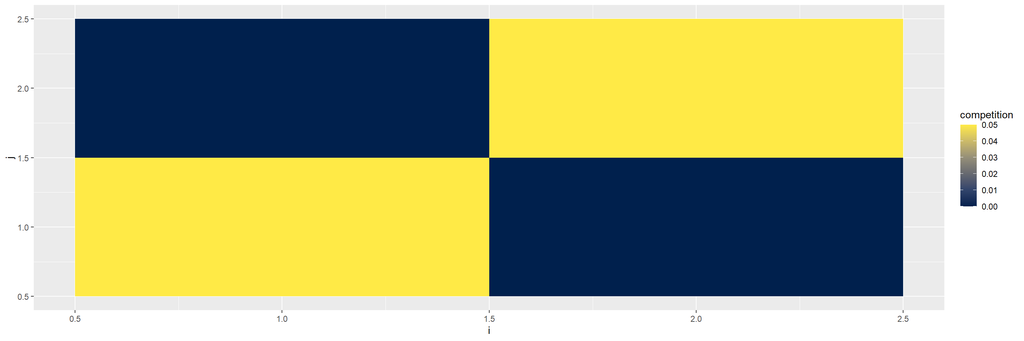

At the end of simulation. Two plots are displayed - (i) species ‘environmental niche’, (ii) interaction matrix.

The dispersal kernel :

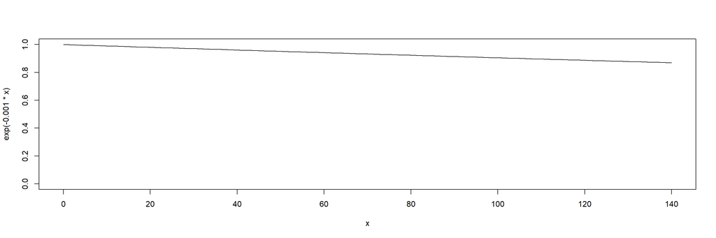

```r
curve(exp(-0.001*x), xlim = c(0,140), ylim = c(0,1)) # Max distance among patch is ca. 140 units
```

You can also plot patches in space, with their environmental value to see how environmental values are clustered in space.

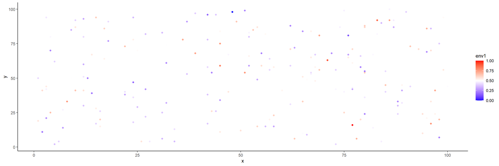

```r
plots_envt(sim)
```

In the end, you also have some helper functions to gather some data from the simulation output :

To get environmental values and geographical positions :

```r
data_envt = get_envt(sim)
data_geo = get_geoposition(sim)
```

And to get abundances and/or occupancies (i.e. presence/absence)

```r
abundances = sim_to_matrix(sim)
occupancies = abund_to_occ(abundances)
```

And lastly, it’s possible to plot directly occupancies over time for all species:

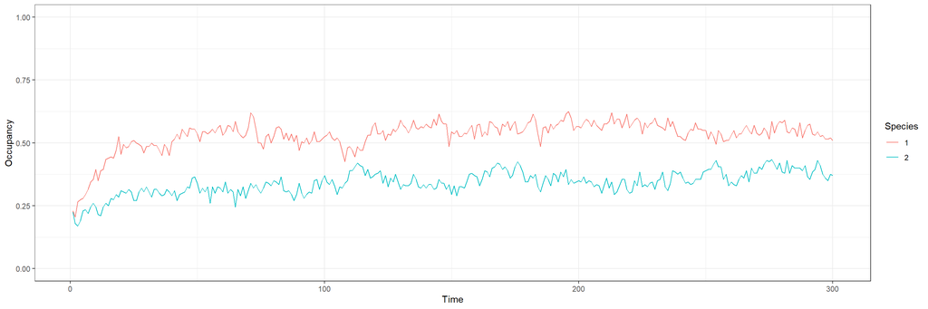

```r
plots_occupancies(occupancies)
```

We will work on occupancy data (i.e. presences / absences)

All models used after can be download from https://github.com/mxdub/TMDSpatial_data/model/ and put into a model/ folder within our working directory.

## One species

### Simple metapopulation model (MacKenzie like) - with time-constant colonization rate

A simple occupancy model is the one from MacKenzie et al. 2003.

Probability of occupancy can be define as :

$$x_t = x_{t-1} (1-\epsilon) + (1 -
x_{t-1}) \gamma$$

Where both $\epsilon$ and $\gamma$ are constant probabilities.

JAGS implementation is given in the MacKenzie_mp file :

```r
model{

  # Define the underlying model - as well as the observation process (although not used here - d = 1)
  for(i in 1:n_site){
    for(j in 2:n_year){
        obs[i,j] ~ dbern(x[i,j]*detec)
        x[i,j] ~ dbern( x[i,j-1] * (1-e) + (1-x[i,j-1])*c )
    }
  }


  # For first year, init with from psi parameter (because the first needs to be fitted)
  for(i in 1:n_site){
    x[i,1] ~ dbern(psi)
  }

  # Logit link
  logit(e) = e_log
  logit(c) = c_log
  logit(psi) = psi_log
  # logit(detec) = detec_log
  detec = 1


  # Define prior for e/c/psi on logit scale
  e_log ~ dnorm(0, 0.1)
  c_log ~ dnorm(0, 0.1)
  psi_log ~ dnorm(0, 0.1)
  # detec_log ~ dnorm(0, 0.1)

}
```

Prepare data for JAGS :

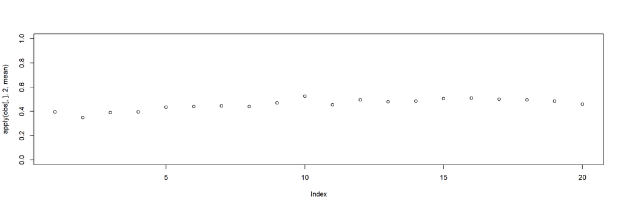

```r
# Prepare data

serie_length = 20
start_point = 10
species = 1

obs = occupancies[,,start_point:(start_point+serie_length-1)]
obs = obs[species,,]

plot(apply(obs[,], 2, mean), ylim = c(0,1))
```

```r
# Define # of patch & # of years
n_site = dim(obs)[1]
n_year = dim(obs)[2]

# Create a datalist for JAGS (with needed variables)
datax <- list(obs = obs,
              n_site = dim(obs)[1],
              n_year = dim(obs)[2])

# And also some inits values (only for patch state - needed to replace NA)
x = obs
x[is.na(x)] = sample(c(0,1), sum(is.na(x)), replace = T)
inits = list(list(x = x))
```

Then, fit the model and simulate data

```r
parameters <- c('e', 'c', 'psi', 'detec')

jm = jags(model.file = "./model/MacKenzie_mp",
          data = datax,
          inits = inits,
          n.chains = 1,
          n.iter = 1000,
          n.burnin = 500,
          n.thin = 5,
          parameters.to.save = parameters)
```

```
## module glm loaded
```

```r
# traceplot(jm)

# Estimates from JAGS
print(jm)
```

```
## Inference for Bugs model at "./model/MacKenzie_mp", fit using jags,
##  1 chains, each with 1000 iterations (first 500 discarded), n.thin = 5
##  n.sims = 100 iterations saved
##          mu.vect sd.vect  2.5%   25%   50%   75% 97.5%
## c          0.145   0.008 0.129 0.140 0.146 0.151 0.158
## detec      1.000   0.000 1.000 1.000 1.000 1.000 1.000
## e          0.157   0.009 0.140 0.151 0.158 0.163 0.173
## psi        0.294   0.054 0.196 0.254 0.295 0.330 0.389
## deviance   0.000   0.000 0.000 0.000 0.000 0.000 0.000
##
## DIC info (using the rule, pD = var(deviance)/2)
## pD = 0.0 and DIC = 0.0
## DIC is an estimate of expected predictive error (lower deviance is better).
```

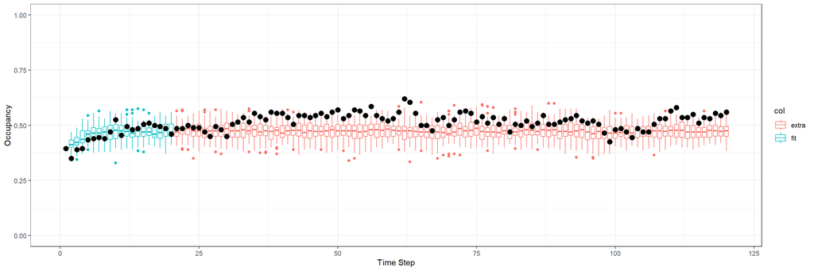

```r
# Comparing simulated from estimates to observed

# Gather parameters from JAGS (whole sampled posterior distribution)
e = jm$BUGSoutput$sims.list$e
c = jm$BUGSoutput$sims.list$c

# Set parameters for simulation (50 replicates, for 100 more time steps than used for fitting)

n_rep = 50
time_out_fit = 100
samples_length = length(e)


rep = matrix(0, ncol = serie_length+time_out_fit, nrow = n_rep)
z = matrix(0, ncol = serie_length+time_out_fit, nrow = n_site)

for(r in 1:n_rep){
  z[,1] = obs[,1]
  draw = sample(1:samples_length, 1)
  for(i in 2:(serie_length+time_out_fit))
    # Simulate patch dynamic (including uncertainty from the posterior distributions)
    z[,i] = sapply(z[,i-1]*(1-e[draw])+(1-z[,i-1])*c[draw], FUN = function(x) rbinom(1,1,x) )
  rep[r,] = apply(z, 2, mean)
}

# Reformat for plotting

rep = as_tibble(rep) %>%
  rownames_to_column() %>%
  pivot_longer(-rowname) %>%
  mutate(name = map_dbl(.x = name,
                        .f = function(x) as.numeric(str_remove(x, 'V')))) %>%
  mutate(col = case_when(name %in% 1:serie_length ~ 'fit', TRUE ~ 'extra')  )
obs_ = occupancies[species,,start_point:(start_point+serie_length-1+time_out_fit)]
obs_ = tibble(year = 1:(serie_length+time_out_fit),
              x = apply(obs_, 2, mean))


ggplot(rep)+
  geom_boxplot(aes(x = name, y = value, group = name, color = col))+
  geom_point(data = obs_, aes(x=year, y = x), size = 3)+
  scale_y_continuous(limits = c(0,1))+
  labs(y='Occupancy', x='Time Step')+
  theme_bw()
```

### Simple metapopulation model (MacKenzie like) - with time-dependent colonization rate

How could write a model with time dependent colonization rate ? Could that be used for projections ?

### Simple metapopulation model (more Levins like) - with colonization rate depending on mp occupancy

Following Levins metapopulation model, colonization rate should depends on proportion of occupied patches.

A new model can be write following :

$$x_{t+1} = x_{t} (1-\epsilon) + (1 -
x_{t}) \gamma_t$$

with

$$\gamma_t = 1 -
e^{-c.\bar{x_t}}$$

Note, $c$ is now a rate and not a probability (see line 20 in the Levins_like model - we are therefor using the log() instead of logit())

```r
parameters <- c('e', 'c', 'psi', 'detec')

jm = jags(model.file = "./model/Levins_like",
          data = datax,
            inits = inits,
          n.chains = 1,
          n.iter = 1000,
          n.burnin = 500,
          n.thin = 5,
          parameters.to.save = parameters)
```

```r
# traceplot(jm)

print(jm)
```

```
## Inference for Bugs model at "./model/Levins_like", fit using jags,
##  1 chains, each with 1000 iterations (first 500 discarded), n.thin = 5
##  n.sims = 100 iterations saved
##          mu.vect sd.vect  2.5%   25%   50%   75% 97.5%
## c          0.343   0.019 0.311 0.329 0.343 0.355 0.387
## detec      1.000   0.000 1.000 1.000 1.000 1.000 1.000
## e          0.155   0.010 0.138 0.148 0.154 0.162 0.173
## psi        0.333   0.042 0.256 0.306 0.334 0.361 0.418
## deviance   0.000   0.000 0.000 0.000 0.000 0.000 0.000
##
## DIC info (using the rule, pD = var(deviance)/2)
## pD = 0.0 and DIC = 0.0
## DIC is an estimate of expected predictive error (lower deviance is better).
```

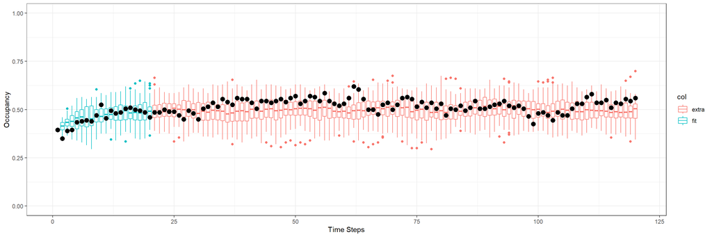

```r
# Simulated

e = jm$BUGSoutput$sims.list$e
c = jm$BUGSoutput$sims.list$c

time_out_fit = 100
samples_length = length(e)

rep = matrix(0, ncol = serie_length+time_out_fit, nrow = n_rep)
z = matrix(0, ncol = serie_length+time_out_fit, nrow = n_site)
for(r in 1:n_rep){
  z[,1] = obs[,1]
  draw = sample(1:samples_length, 1)
  for(i in 2:(serie_length+time_out_fit))
    z[,i] = sapply(z[,i-1]*(1-e[draw])+(1-z[,i-1])*(1-exp(-c[draw]*mean(z[,i-1]))), FUN = function(x) rbinom(1,1,x) )
  rep[r,] = apply(z, 2, mean)
}

# Reformat for plotting

rep = as_tibble(rep) %>%
  rownames_to_column() %>%
  pivot_longer(-rowname) %>%
  mutate(name = map_dbl(.x = name,
                        .f = function(x) as.numeric(str_remove(x, 'V')))) %>%
  mutate(col = case_when(name %in% 1:serie_length ~ 'fit', TRUE ~ 'extra')  )

obs_ = occupancies[species,,start_point:(start_point+serie_length-1+time_out_fit)]
obs_ = tibble(year = 1:(serie_length+time_out_fit),
              x = apply(obs_, 2, mean))


ggplot(rep)+
  geom_boxplot(aes(x = name, y = value, group = name, color = col))+
  geom_point(data = obs_, aes(x=year, y = x), size = 3)+
  scale_y_continuous(limits = c(0,1))+
  labs(y='Occupancy', x='Time Steps')+
  theme_bw()
```

### Simple metapopulation model (MacKenzie like) - with environmental effects on demographic rates

Let now reuse MacKenzie model, but including environmental covariates.

The model takes the following form :

$$x_{i,t} = x_{i,t-1} (1-\epsilon_i) + (1
- x_{i,t-1}) \gamma_i$$

Both extinction and colonization parameters are now site-specific (i.e. $\epsilon_i$, $\gamma_i$), because they are probabilities (within $[0,1]$), a logit() transform have to be used to regress them on environmental variables.

$$\epsilon_i =
\frac{1}{1+e^{-(\mu_{\epsilon}+\mathbf{\beta_{\epsilon}}X)}}, \gamma_i =
\frac{1}{1+e^{-(\mu_{\gamma}+\mathbf{\beta_{\gamma}}X)}}$$

```r
# We now need to include environmental data
# Using scaled variable and quadratic effect !

dt_envt_scaled = as.data.frame(scale(data_envt))
dt_envt_scaled$env1sqr = (dt_envt_scaled$env1)^2

datax <- list(obs = obs,
              n_site = dim(obs)[1],
              n_year = dim(obs)[2],
              envt = dt_envt_scaled)

parameters <- c('psi', 'mu_c', 'mu_e', 'beta_c', 'beta_e', 'beta_sqr_c', 'beta_sqr_e')

jm = jags(model.file = "./model/MacKenzie_mp_envt",
          data = datax,
            inits = inits,
          n.chains = 1,
          n.iter = 2000,
          n.burnin = 500,
          n.thin = 5,
          parameters.to.save = parameters)
```

```r
# traceplot(jm)

# library(ggmcmc)
# ggmcmc(ggs(as.mcmc(jm$BUGSoutput$sims.array[,1,])), file = './output1.pdf' )

print(jm)
```

```
## Inference for Bugs model at "./model/MacKenzie_mp_envt", fit using jags,
##  1 chains, each with 2000 iterations (first 500 discarded), n.thin = 5
##  n.sims = 300 iterations saved
##            mu.vect sd.vect   2.5%    25%    50%    75%  97.5%
## beta_c      -0.002   0.063 -0.118 -0.047 -0.002  0.041  0.127
## beta_e       2.406   0.148  2.140  2.298  2.397  2.517  2.705
## beta_sqr_c  -0.062   0.039 -0.135 -0.088 -0.060 -0.038  0.010
## beta_sqr_e   1.653   0.135  1.416  1.556  1.644  1.755  1.913
## mu_c        -1.718   0.073 -1.868 -1.760 -1.718 -1.671 -1.580
## mu_e        -2.191   0.107 -2.403 -2.266 -2.186 -2.113 -2.007
## psi          0.452   0.058  0.333  0.411  0.456  0.494  0.555
## deviance     0.000   0.000  0.000  0.000  0.000  0.000  0.000
##
## DIC info (using the rule, pD = var(deviance)/2)
## pD = 0.0 and DIC = 0.0
## DIC is an estimate of expected predictive error (lower deviance is better).
```

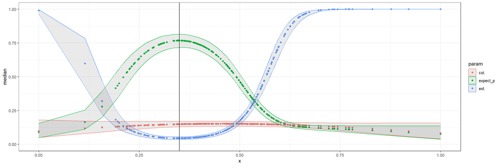

```r
# Remember, parameters are given in a logit scale, and therefor need to be backtransformed
inv.logit = function(x) 1/(1+exp(-x))

c_related_param = jm$BUGSoutput$sims.array[,1,c('mu_c', 'beta_c', 'beta_sqr_c')]
e_related_param = jm$BUGSoutput$sims.array[,1,c('mu_e', 'beta_e', 'beta_sqr_e')]

envt_matrix = as.matrix(tibble(intcp = 1, env1 = dt_envt_scaled[,1]) %>% mutate(env1sqr = env1^2))

c_boot = inv.logit(c_related_param %*% t(envt_matrix))
e_boot = inv.logit(e_related_param %*% t(envt_matrix))

plot_envt_effect(data_envt$env1, c_boot, e_boot, envt_opt[species])
```

```r
## Presence probabilities

# plot(apply(p_boot, 2, median) ~ apply(occupancies[species,,], 1, mean), xlim = c(0,1), ylim = c(0,1))
```

Some thoughts… Why colonization rate never reach zero ? What’s telling us about the (simulation) model ?

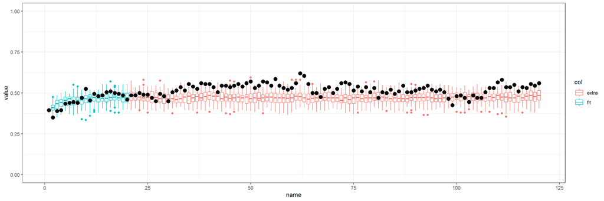

```r
## Add simulation ?

n_rep = 50
time_out_fit = 100
samples_length = dim(c_related_param)[1]

rep = matrix(0, ncol = serie_length+time_out_fit, nrow = n_rep)
z = matrix(0, ncol = serie_length+time_out_fit, nrow = n_site)

for(r in 1:n_rep){
  z[,1] = obs[,1]
  draw = sample(1:samples_length, 1)
  for(i in 2:(serie_length+time_out_fit))
    # Simulate patch dynamic (including uncertainty from the posterior distributions)
    z[,i] = sapply(z[,i-1]*(1-inv.logit((e_related_param[draw,] %*% t(envt_matrix))[1,]))+
                  (1-z[,i-1])*inv.logit((c_related_param[draw,] %*% t(envt_matrix))[1,]),
                  FUN = function(x) rbinom(1,1,x) )
  rep[r,] = apply(z, 2, mean)
}

# Reformat for plotting

rep = as_tibble(rep) %>%
  rownames_to_column() %>%
  pivot_longer(-rowname) %>%
  mutate(name = map_dbl(.x = name,
                        .f = function(x) as.numeric(str_remove(x, 'V')))) %>%
  mutate(col = case_when(name %in% 1:serie_length ~ 'fit', TRUE ~ 'extra')  )

obs_ = occupancies[species,,start_point:(start_point+serie_length-1+time_out_fit)]
obs_ = tibble(year = 1:(serie_length+time_out_fit),
              x = apply(obs_, 2, mean))

ggplot(rep)+
  geom_boxplot(aes(x = name, y = value, group = name, color = col))+
  geom_point(data = obs_, aes(x=year, y = x), size = 3)+
  scale_y_continuous(limits = c(0,1))+
  theme_bw()
```

```r
## Presence probabilities

# plot(apply(p_boot, 2, median) ~ apply(occupancies[species,,], 1, mean), xlim = c(0,1), ylim = c(0,1))
```

# Going further…

### And with density-dependent colonization ?

```r
jm = jags(model.file = "./model/Levins_like_envt",
          data = datax,
            inits = inits,
          n.chains = 1,
          n.iter = 2000,
          n.burnin = 500,
          n.thin = 5,
          parameters.to.save = parameters)
```

```r
# traceplot(jm)

print(jm)
```

```
## Inference for Bugs model at "./model/Levins_like_envt", fit using jags,
##  1 chains, each with 2000 iterations (first 500 discarded), n.thin = 5
##  n.sims = 300 iterations saved
##            mu.vect sd.vect   2.5%    25%    50%    75%  97.5%
## beta_c       0.006   0.059 -0.116 -0.032  0.006  0.047  0.123
## beta_e       2.400   0.162  2.097  2.293  2.400  2.520  2.714
## beta_sqr_c  -0.061   0.039 -0.142 -0.087 -0.059 -0.035  0.011
## beta_sqr_e   1.642   0.141  1.383  1.541  1.637  1.728  1.910
## mu_c        -1.019   0.076 -1.181 -1.067 -1.018 -0.967 -0.880
## mu_e        -2.188   0.111 -2.394 -2.261 -2.183 -2.111 -1.983
## psi          0.469   0.059  0.357  0.433  0.470  0.510  0.582
## deviance     0.000   0.000  0.000  0.000  0.000  0.000  0.000
##
## DIC info (using the rule, pD = var(deviance)/2)
## pD = 0.0 and DIC = 0.0
## DIC is an estimate of expected predictive error (lower deviance is better).
```

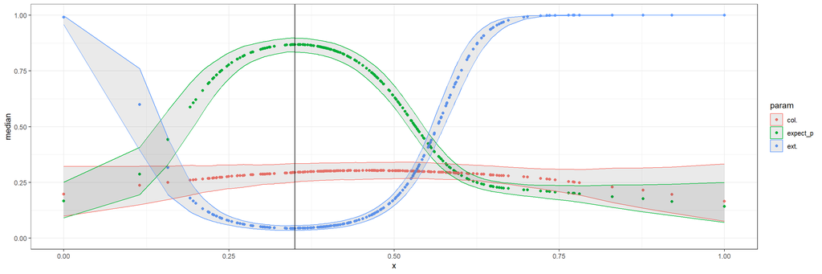

```r
# Remember, parameters are given in a logit scale, and therefor need to be backtransformed
inv.logit = function(x) 1/(1+exp(-x))

c_related_param = jm$BUGSoutput$sims.array[,1,c('mu_c', 'beta_c', 'beta_sqr_c')]
e_related_param = jm$BUGSoutput$sims.array[,1,c('mu_e', 'beta_e', 'beta_sqr_e')]

envt_matrix = as.matrix(tibble(intcp = 1, env1 = dt_envt_scaled[,1]) %>% mutate(env1sqr = env1^2))

mp_occupancy = 1 # Assuming a full metapopulation

c_boot = (1-exp(-exp(c_related_param %*% t(envt_matrix))*mp_occupancy))
e_boot = inv.logit(e_related_param %*% t(envt_matrix))

plot_envt_effect(data_envt$env1, c_boot, e_boot, envt_opt[species])
```

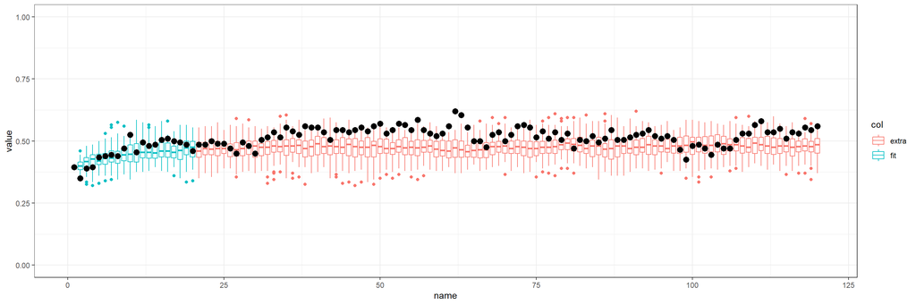

```r
## Add simulation ?

n_rep = 50
time_out_fit = 100
samples_length = dim(c_related_param)[1]

rep = matrix(0, ncol = serie_length+time_out_fit, nrow = n_rep)
z = matrix(0, ncol = serie_length+time_out_fit, nrow = n_site)

for(r in 1:n_rep){
  z[,1] = obs[,1]
  draw = sample(1:samples_length, 1)
  for(i in 2:(serie_length+time_out_fit))
    # Simulate patch dynamic (including uncertainty from the posterior distributions)
    z[,i] = sapply(z[,i-1]*(1-inv.logit((e_related_param[draw,] %*% t(envt_matrix))[1,]))+
                  (1-z[,i-1])*(1-exp(-exp((c_related_param[draw,] %*% t(envt_matrix))[1,])*mean(z[,i-1]))),
                  FUN = function(x) rbinom(1,1,x) )
  rep[r,] = apply(z, 2, mean)
}


# Reformat for plotting

rep = as_tibble(rep) %>%
  rownames_to_column() %>%
  pivot_longer(-rowname) %>%
  mutate(name = map_dbl(.x = name,
                        .f = function(x) as.numeric(str_remove(x, 'V')))) %>%
  mutate(col = case_when(name %in% 1:serie_length ~ 'fit', TRUE ~ 'extra')  )

obs_ = occupancies[species,,start_point:(start_point+serie_length-1+time_out_fit)]
obs_ = tibble(year = 1:(serie_length+time_out_fit),
              x = apply(obs_, 2, mean))


ggplot(rep)+
  geom_boxplot(aes(x = name, y = value, group = name, color = col))+
  geom_point(data = obs_, aes(x=year, y = x), size = 3)+
  scale_y_continuous(limits = c(0,1))+
  theme_bw()
```

## More than one species (well, two…)

They are the same models as previously but include an additional dimension !

Let’s simulate new data, but with competitive interactions now !

```r
n_patch = 200
n_species = 2

# Define environmental optima
envt_opt = c(0.40, 0.6)

sim = simulate_MC(patches = n_patch,     # Number of patch
                  species = n_species,   # Number of species
                  kernel_exp = 0.001,    # Rate of decrease of disp. kernel (e.g. P(disp) = exp(-kernel_exp*dist(i,j)))
                  env1Scale = 100,       # Low spatial autocorrelation for envt (not important)
                  env_optima = envt_opt, # Environmental effects are Gaussian around optimum
                  env_niche_breadth = 0.09, # Niche breadth (~ sd of the Gaussian)
                  int_mat = matrix( c(0.05,0.1,
                                      0.01,0.05) , nrow = 2, ncol = 2), # Interaction matrix
                  local_start = F) # Whether to start with clusered pop. or not
```

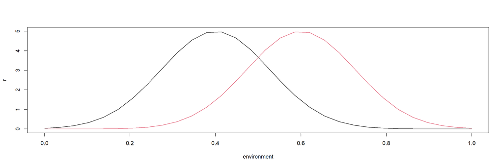

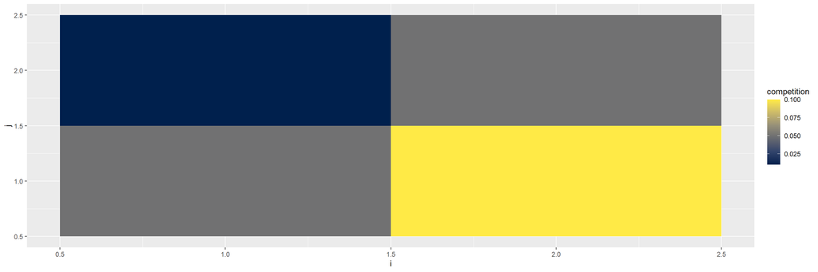

```r
data_envt = get_envt(sim)


abundances = sim_to_matrix(sim)
occupancies = abund_to_occ(abundances)
```

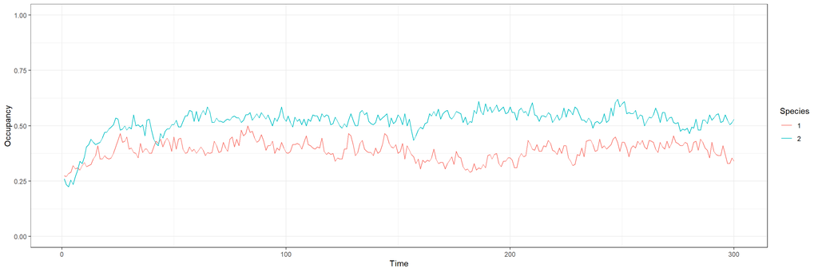

```r
plots_occupancies(occupancies)
```

Prepare data for JAGS :

```r
# Prepare data

serie_length = 20
start_point = 50

obs = occupancies[,,start_point:(start_point+serie_length-1)]


# Define # of patch & # of years
n_species = dim(obs)[1]
n_site = dim(obs)[2]
n_year = dim(obs)[3]

dt_envt_scaled = as.data.frame(scale(data_envt))
dt_envt_scaled$env1sqr = (dt_envt_scaled$env1)^2

# Create a datalist for JAGS (with needed variables)
datax <- list(obs = obs,
              n_species = n_species,
              n_site = n_site,
              n_year = n_year,
              envt = dt_envt_scaled)

parameters <- c('psi', 'mu_c', 'mu_e', 'beta_c', 'beta_e', 'beta_sqr_c', 'beta_sqr_e')

# And also some inits values (only for patch state - needed to replace NA)
x = obs
x[is.na(x)] = sample(c(0,1), sum(is.na(x)), replace = T)
inits = list(list(x = x))
```

### Time-constant colonization

```r
jm = jags(model.file = "./model/MacKenzie_mp_envt_morespecies",
          data = datax,
            inits = inits,
          n.chains = 1,
          n.iter = 2000,
          n.burnin = 500,
          n.thin = 5,
          parameters.to.save = parameters)
print(jm)
```

```
## Inference for Bugs model at "./model/MacKenzie_mp_envt_morespecies", fit using jags,
##  1 chains, each with 2000 iterations (first 500 discarded), n.thin = 5
##  n.sims = 300 iterations saved
##               mu.vect sd.vect   2.5%    25%    50%    75%  97.5%
## beta_c[1]       0.002   0.065 -0.123 -0.046  0.005  0.049  0.111
## beta_c[2]      -0.040   0.052 -0.137 -0.077 -0.038 -0.003  0.053
## beta_e[1]       2.146   0.159  1.845  2.040  2.141  2.251  2.467
## beta_e[2]      -1.251   0.106 -1.462 -1.320 -1.258 -1.178 -1.049
## beta_sqr_c[1]  -0.032   0.051 -0.134 -0.064 -0.032  0.005  0.057
## beta_sqr_c[2]  -0.023   0.045 -0.109 -0.055 -0.019  0.007  0.058
## beta_sqr_e[1]   1.823   0.134  1.541  1.740  1.829  1.919  2.049
## beta_sqr_e[2]   1.268   0.092  1.092  1.213  1.269  1.323  1.451
## mu_c[1]        -1.956   0.097 -2.150 -2.016 -1.956 -1.885 -1.786
## mu_c[2]        -1.600   0.095 -1.767 -1.664 -1.602 -1.546 -1.400
## mu_e[1]        -2.057   0.107 -2.266 -2.134 -2.053 -1.982 -1.829
## mu_e[2]        -2.561   0.103 -2.755 -2.624 -2.562 -2.492 -2.346
## psi[1]          0.561   0.057  0.440  0.527  0.564  0.599  0.670
## psi[2]          0.621   0.053  0.509  0.588  0.626  0.659  0.715
## deviance        0.000   0.000  0.000  0.000  0.000  0.000  0.000
##
## DIC info (using the rule, pD = var(deviance)/2)
## pD = 0.0 and DIC = 0.0
## DIC is an estimate of expected predictive error (lower deviance is better).
```

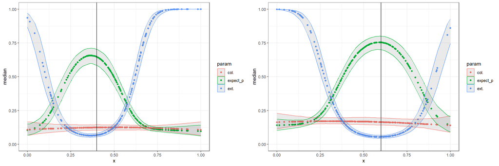

```r
c_related_param = list(jm$BUGSoutput$sims.array[,1,c('mu_c[1]', 'beta_c[1]', 'beta_sqr_c[1]')],
                       jm$BUGSoutput$sims.array[,1,c('mu_c[2]', 'beta_c[2]', 'beta_sqr_c[2]')])
e_related_param = list(jm$BUGSoutput$sims.array[,1,c('mu_e[1]', 'beta_e[1]', 'beta_sqr_e[1]')],
                       jm$BUGSoutput$sims.array[,1,c('mu_e[2]', 'beta_e[2]', 'beta_sqr_e[2]')])

envt_matrix = as.matrix(tibble(intcp = 1, env1 = dt_envt_scaled[,1]) %>% mutate(env1sqr = env1^2))

c_boot = list( inv.logit(c_related_param[[1]] %*% t(envt_matrix)),
               inv.logit(c_related_param[[2]] %*% t(envt_matrix)) )

e_boot = list( inv.logit(e_related_param[[1]] %*% t(envt_matrix)),
               inv.logit(e_related_param[[2]] %*% t(envt_matrix)) )


cowplot::plot_grid(plot_envt_effect(data_envt$env1, c_boot[[1]], e_boot[[1]], envt_opt[1]),
                    plot_envt_effect(data_envt$env1, c_boot[[2]], e_boot[[2]], envt_opt[2]),
                   ncol = 2)
```

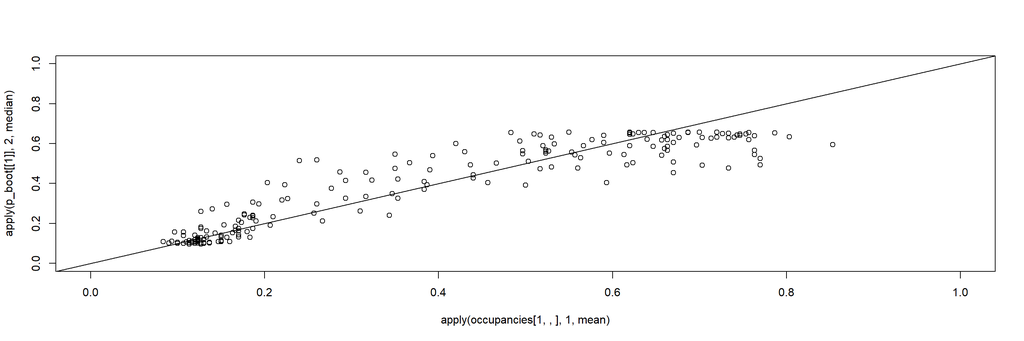

```r
## Presence probabilities
p_boot = list(c_boot[[1]]/(c_boot[[1]]+e_boot[[1]]),
              c_boot[[2]]/(c_boot[[2]]+e_boot[[2]]))
plot(apply(p_boot[[1]], 2, median) ~ apply(occupancies[1,,], 1, mean), xlim = c(0,1), ylim = c(0,1))
abline(a=0, b=1, add = TRUE)
```

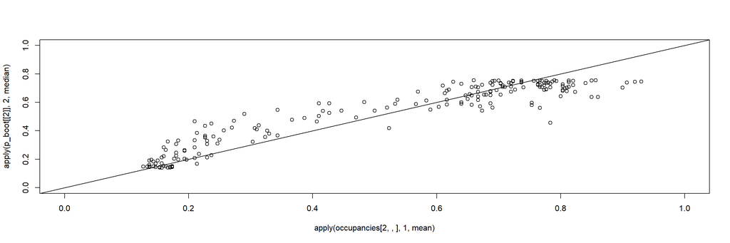

```r
plot(apply(p_boot[[2]], 2, median) ~ apply(occupancies[2,,], 1, mean), xlim = c(0,1), ylim = c(0,1))
abline(a=0, b=1, add = TRUE)
```

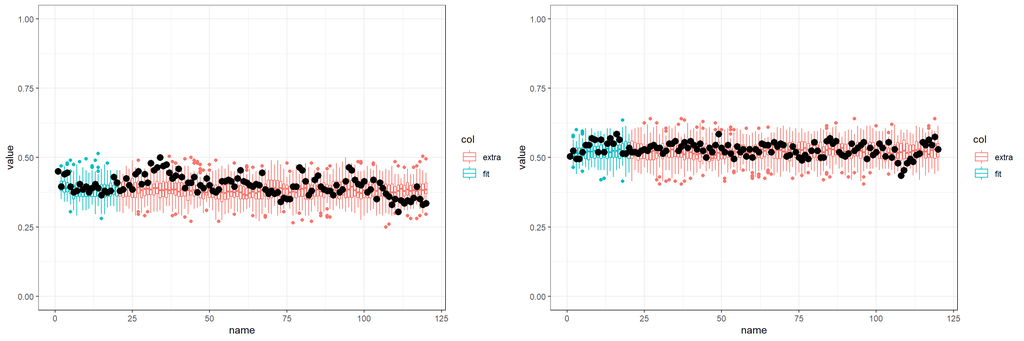

```r
## Add simulation ?

n_rep = 50
time_out_fit = 100
samples_length = dim(c_related_param[[1]])[1]

rep = structure(.Data = rep(0, n_species*n_rep*(serie_length+time_out_fit)),
              .Dim = c(n_species, n_rep, serie_length+time_out_fit))
z = structure(.Data = rep(0, n_species*n_site*(serie_length+time_out_fit)),
              .Dim = c(n_species, n_site, serie_length+time_out_fit))

  for(r in 1:n_rep){

    z[,,1] = obs[,,1]
    draw = sample(1:samples_length, 1)

    for(i in 2:(serie_length+time_out_fit)){
        for(s in 1:n_species){
           # Simulate patch dynamic (including uncertainty from the posterior distributions)
            z[s,,i] = sapply(z[s,,i-1]*(1-inv.logit((e_related_param[[s]][draw,] %*% t(envt_matrix))[1,]))+
                          (1-z[s,,i-1])*inv.logit((c_related_param[[s]][draw,] %*% t(envt_matrix))[1,]),
                          FUN = function(x) rbinom(1,1,x) )
        }
    }
    rep[,r,] = apply(z[,,], c(1,3), mean)
  }


# Reformat for plotting
g = list()
for(s in 1:n_species){
  rep_ = as_tibble(rep[s,,]) %>%
    rownames_to_column() %>%
    pivot_longer(-rowname) %>%
    mutate(name = map_dbl(.x = name,
                          .f = function(x) as.numeric(str_remove(x, 'V')))) %>%
    mutate(col = case_when(name %in% 1:serie_length ~ 'fit', TRUE ~ 'extra')  )

  obs_ = occupancies[s,,start_point:(start_point+serie_length-1+time_out_fit)]
  obs_ = tibble(year = 1:(serie_length+time_out_fit),
                x = apply(obs_, 2, mean))

  g[[s]] = ggplot(rep_)+
    geom_boxplot(aes(x = name, y = value, group = name, color = col))+
    geom_point(data = obs_, aes(x=year, y = x), size = 3)+
    scale_y_continuous(limits = c(0,1))+
    theme_bw()
}

cowplot::plot_grid(g[[1]], g[[2]], ncol=2)
```

### Time-varying colonization

What kind of improvement can be made on such models ? (think HMSC)

### Interacting species ?

```r
datax <- list(obs = obs,
              n_species = n_species,
              n_site = n_site,
              n_year = n_year,
              envt = dt_envt_scaled,
              switch = c(2,1) )

parameters <- c('psi', 'mu_c', 'mu_e', 'beta_c', 'beta_e', 'beta_sqr_c', 'beta_sqr_e', 'gamma_e', 'gamma_c')

jm = jags(model.file = "./model/MacKenzie_mp_envt_morespecies_interacting",
          data = datax,
            inits = inits,
          n.chains = 1,
          n.iter = 3000,
          n.burnin = 100,
          n.thin = 5,
          parameters.to.save = parameters)
print(jm)
```

```
## Inference for Bugs model at "./model/MacKenzie_mp_envt_morespecies_interacting", fit using jags,
##  1 chains, each with 3000 iterations (first 100 discarded), n.thin = 5
##  n.sims = 580 iterations saved
##               mu.vect sd.vect   2.5%    25%    50%    75%  97.5%
## beta_c[1]       0.013   0.065 -0.109 -0.032  0.009  0.055  0.147
## beta_c[2]      -0.058   0.056 -0.171 -0.096 -0.058 -0.020  0.047
## beta_e[1]       1.955   0.160  1.674  1.841  1.956  2.049  2.284
## beta_e[2]      -1.127   0.104 -1.323 -1.193 -1.124 -1.059 -0.935
## beta_sqr_c[1]  -0.055   0.050 -0.150 -0.092 -0.057 -0.020  0.041
## beta_sqr_c[2]  -0.057   0.048 -0.148 -0.089 -0.058 -0.025  0.042
## beta_sqr_e[1]   1.895   0.133  1.637  1.808  1.889  1.985  2.164
## beta_sqr_e[2]   1.303   0.094  1.126  1.242  1.298  1.363  1.487
## gamma_c[1]     -0.161   0.108 -0.410 -0.230 -0.139 -0.074 -0.013
## gamma_c[2]     -0.207   0.121 -0.480 -0.284 -0.196 -0.119 -0.021
## gamma_e[1]      0.847   0.200  0.446  0.712  0.844  0.987  1.239
## gamma_e[2]      0.578   0.167  0.258  0.470  0.572  0.684  0.902
## mu_c[1]        -1.834   0.117 -2.037 -1.922 -1.845 -1.755 -1.596
## mu_c[2]        -1.451   0.119 -1.685 -1.531 -1.450 -1.376 -1.213
## mu_e[1]        -2.633   0.183 -3.000 -2.765 -2.618 -2.494 -2.301
## mu_e[2]        -2.850   0.142 -3.134 -2.943 -2.846 -2.756 -2.577
## psi[1]          0.567   0.058  0.452  0.529  0.569  0.609  0.685
## psi[2]          0.626   0.054  0.523  0.593  0.623  0.663  0.733
## deviance        0.000   0.000  0.000  0.000  0.000  0.000  0.000
##
## DIC info (using the rule, pD = var(deviance)/2)
## pD = 0.0 and DIC = 0.0
## DIC is an estimate of expected predictive error (lower deviance is better).
```

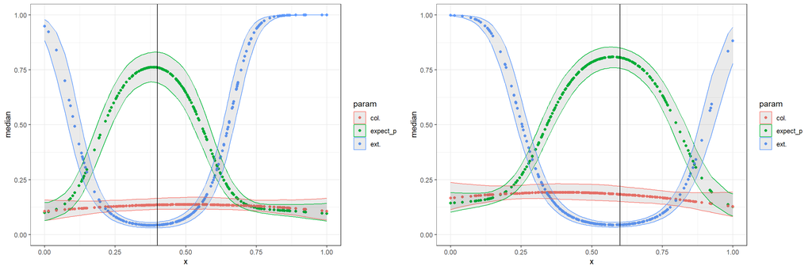

```r
c_related_param = list(jm$BUGSoutput$sims.array[,1,c('mu_c[1]', 'beta_c[1]', 'beta_sqr_c[1]')],
                       jm$BUGSoutput$sims.array[,1,c('mu_c[2]', 'beta_c[2]', 'beta_sqr_c[2]')])
e_related_param = list(jm$BUGSoutput$sims.array[,1,c('mu_e[1]', 'beta_e[1]', 'beta_sqr_e[1]')],
                       jm$BUGSoutput$sims.array[,1,c('mu_e[2]', 'beta_e[2]', 'beta_sqr_e[2]')])

#
# c_boot = (1-exp(-exp(c_related_param %*% t(envt_matrix))*mp_occupancy))
# e_boot = inv.logit(e_related_param %*% t(envt_matrix))


envt_matrix = as.matrix(tibble(intcp = 1, env1 = dt_envt_scaled[,1]) %>% mutate(env1sqr = env1^2))

# W/o interactions

c_boot = list( inv.logit(c_related_param[[1]] %*% t(envt_matrix)),
               inv.logit(c_related_param[[2]] %*% t(envt_matrix)) )

e_boot = list( inv.logit(e_related_param[[1]] %*% t(envt_matrix)),
               inv.logit(e_related_param[[2]] %*% t(envt_matrix)) )

gamma_e = jm$BUGSoutput$sims.array[,1,c('gamma_e[1]', 'gamma_e[2]')]
gamma_c = jm$BUGSoutput$sims.array[,1,c('gamma_c[1]', 'gamma_c[2]')]

cowplot::plot_grid(plot_envt_effect(data_envt$env1, c_boot[[1]], e_boot[[1]], envt_opt[1]),
                    plot_envt_effect(data_envt$env1, c_boot[[2]], e_boot[[2]], envt_opt[2]),
                   ncol = 2)
```

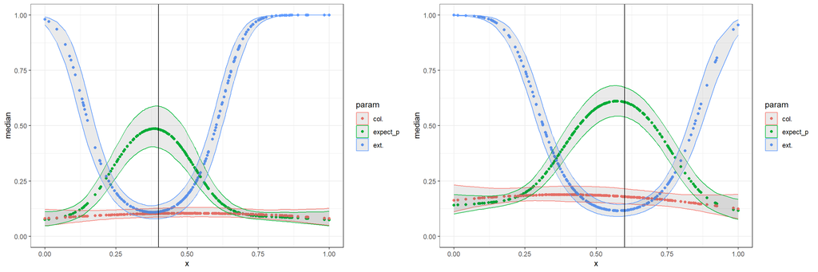

```r
# W/ interactions

gamma_e = jm$BUGSoutput$sims.array[,1,c('gamma_e[1]', 'gamma_e[2]')]
gamma_c = jm$BUGSoutput$sims.array[,1,c('gamma_c[1]', 'gamma_c[2]')]

c_boot = list( inv.logit(c_related_param[[1]] %*% t(envt_matrix) + gamma_c[1]),
               inv.logit(c_related_param[[2]] %*% t(envt_matrix) + gamma_c[2]) )

e_boot = list( inv.logit(e_related_param[[1]] %*% t(envt_matrix) + gamma_e[1]),
               inv.logit(e_related_param[[2]] %*% t(envt_matrix) + gamma_e[2]) )


cowplot::plot_grid(plot_envt_effect(data_envt$env1, c_boot[[1]], e_boot[[1]], envt_opt[1]),
                    plot_envt_effect(data_envt$env1, c_boot[[2]], e_boot[[2]], envt_opt[2]),
                   ncol = 2)
```

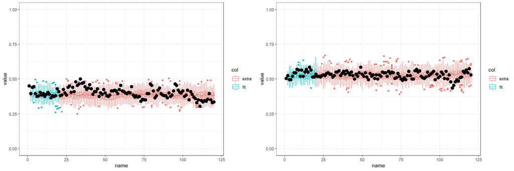

```r
## Add simulation ?

n_rep = 50
time_out_fit = 100
samples_length = dim(c_related_param[[1]])[1]
switchs = c(2, 1)

rep = structure(.Data = rep(0, n_species*n_rep*(serie_length+time_out_fit)),
              .Dim = c(n_species, n_rep, serie_length+time_out_fit))
z = structure(.Data = rep(0, n_species*n_site*(serie_length+time_out_fit)),
              .Dim = c(n_species, n_site, serie_length+time_out_fit))

  for(r in 1:n_rep){
    z[,,1] = obs[,,1]
    draw = sample(1:samples_length, 1)
    for(i in 2:(serie_length+time_out_fit)){
      for(s in 1:n_species){
        # Simulate patch dynamic (including uncertainty from the posterior distributions)
        z[s,,i] = sapply(z[s,,i-1]*(1-inv.logit((e_related_param[[s]][draw,] %*% t(envt_matrix))[1,] + gamma_e[draw,s]*z[switchs[s],,i-1]))+
                      (1-z[s,,i-1])*inv.logit((c_related_param[[s]][draw,] %*% t(envt_matrix))[1,] + gamma_c[draw,s]*z[switchs[s],,i-1]),
                      FUN = function(x) rbinom(1,1,x) )
      }
    }
    rep[,r,] = apply(z[,,], c(1,3), mean)
  }


# Reformat for plotting
g = list()
for(s in 1:n_species){
  rep_ = as_tibble(rep[s,,]) %>%
    rownames_to_column() %>%
    pivot_longer(-rowname) %>%
    mutate(name = map_dbl(.x = name,
                          .f = function(x) as.numeric(str_remove(x, 'V')))) %>%
    mutate(col = case_when(name %in% 1:serie_length ~ 'fit', TRUE ~ 'extra')  )

  obs_ = occupancies[s,,start_point:(start_point+serie_length-1+time_out_fit)]
  obs_ = tibble(year = 1:(serie_length+time_out_fit),
                x = apply(obs_, 2, mean))

  g[[s]] = ggplot(rep_)+
    geom_boxplot(aes(x = name, y = value, group = name, color = col))+
    geom_point(data = obs_, aes(x=year, y = x), size = 3)+
    scale_y_continuous(limits = c(0,1))+
    theme_bw()
}

cowplot::plot_grid(g[[1]], g[[2]], ncol=2)
```

If interaction were not accounted for

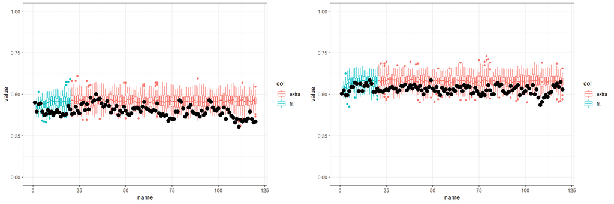

```r
## Add simulation ?

n_rep = 50
time_out_fit = 100
samples_length = dim(c_related_param[[1]])[1]
switchs = c(2, 1)

rep = structure(.Data = rep(0, n_species*n_rep*(serie_length+time_out_fit)),
              .Dim = c(n_species, n_rep, serie_length+time_out_fit))
z = structure(.Data = rep(0, n_species*n_site*(serie_length+time_out_fit)),
              .Dim = c(n_species, n_site, serie_length+time_out_fit))

  for(r in 1:n_rep){
    z[,,1] = obs[,,1]
    draw = sample(1:samples_length, 1)
    for(i in 2:(serie_length+time_out_fit)){
      for(s in 1:n_species){
        # Simulate patch dynamic (including uncertainty from the posterior distributions)
        z[s,,i] = sapply(z[s,,i-1]*(1-inv.logit((e_related_param[[s]][draw,] %*% t(envt_matrix))[1,]))+
                      (1-z[s,,i-1])*inv.logit((c_related_param[[s]][draw,] %*% t(envt_matrix))[1,] ),
                      FUN = function(x) rbinom(1,1,x) )
      }
    }
    rep[,r,] = apply(z[,,], c(1,3), mean)
  }


# Reformat for plotting
g = list()
for(s in 1:n_species){
  rep_ = as_tibble(rep[s,,]) %>%
    rownames_to_column() %>%
    pivot_longer(-rowname) %>%
    mutate(name = map_dbl(.x = name,
                          .f = function(x) as.numeric(str_remove(x, 'V')))) %>%
    mutate(col = case_when(name %in% 1:serie_length ~ 'fit', TRUE ~ 'extra')  )

  obs_ = occupancies[s,,start_point:(start_point+serie_length-1+time_out_fit)]
  obs_ = tibble(year = 1:(serie_length+time_out_fit),
                x = apply(obs_, 2, mean))

  g[[s]] = ggplot(rep_)+
    geom_boxplot(aes(x = name, y = value, group = name, color = col))+
    geom_point(data = obs_, aes(x=year, y = x), size = 3)+
    scale_y_continuous(limits = c(0,1))+
    theme_bw()
}

cowplot::plot_grid(g[[1]], g[[2]], ncol=2)
```